# Final Project

Congqi Lin & Weiting Yu

2022-12-02

```r
rm(list = ls())
#Add libraries as needed
library(tidyverse)
library(FNN)
library(randomForest)
library(e1071)
```

```r
#Import datasets
Gamemodes <- read.csv("C:/Users/AndyL/OneDrive/桌面/22 FALL/STAT380/CODGameModes.csv")
Player1 <- read.csv("C:/Users/AndyL/OneDrive/桌面/22 FALL/STAT380/CODGames_p1_380.csv")
Player2 <- read.csv("C:/Users/AndyL/OneDrive/桌面/22 FALL/STAT380/CODGames_p2_380.csv")
```

## Task 1

```r
#Combine two datasets and change name of GameType
Allplayer <-
  Player1 %>%
  full_join(Player2)
```

[output not shown]

```r
Allplayer["GameType"][Allplayer["GameType"] == "HC - TDM"] <- "TDM"
Allplayer["GameType"][Allplayer["GameType"] == "HC - Kill Confirmed"] <- "Kill Confirmed"
Allplayer["GameType"][Allplayer["GameType"] == "HC - Hardpoint"] <- "Hardpoint"
Allplayer["GameType"][Allplayer["GameType"] == "HC - Domination"] <- "Domination"
```

```r
#Separate Result and add ScoreLimit
Allplayer2 <-
  Allplayer %>%
  separate(Result, c('ResultA','ResultB'),'-') %>%
  mutate(ResultA = as.numeric(ResultA),
         ResultB = as.numeric(ResultB)) %>%
  left_join(Gamemodes, by=c("GameType" = "Mode"))
#Find all games reach score limit and calculate propotion.
ReachNum <-
  Allplayer2 %>%
  mutate(Reach = ifelse(ResultA == ScoreLimit, 1, ifelse(ResultB == ScoreLimit, 1, 0))) %>%
  filter(Reach == "1") %>%
  group_by(GameType) %>%
  summarize(reachnum = n())

TotalNum <-
  Allplayer2 %>%
  group_by(GameType) %>%
  summarize(totalnum = n()) %>%
  full_join(ReachNum) %>%
  mutate(propotion = reachnum / totalnum) %>%
  arrange(desc(propotion))
TotalNum
```

```
## # A tibble: 4 × 4
##   GameType       totalnum reachnum propotion
##   <chr>             <int>    <int>     <dbl>
## 1 Domination           14       14     1
## 2 Hardpoint           267      251     0.940
## 3 TDM                 537      429     0.799
## 4 Kill Confirmed       21       16     0.762
```

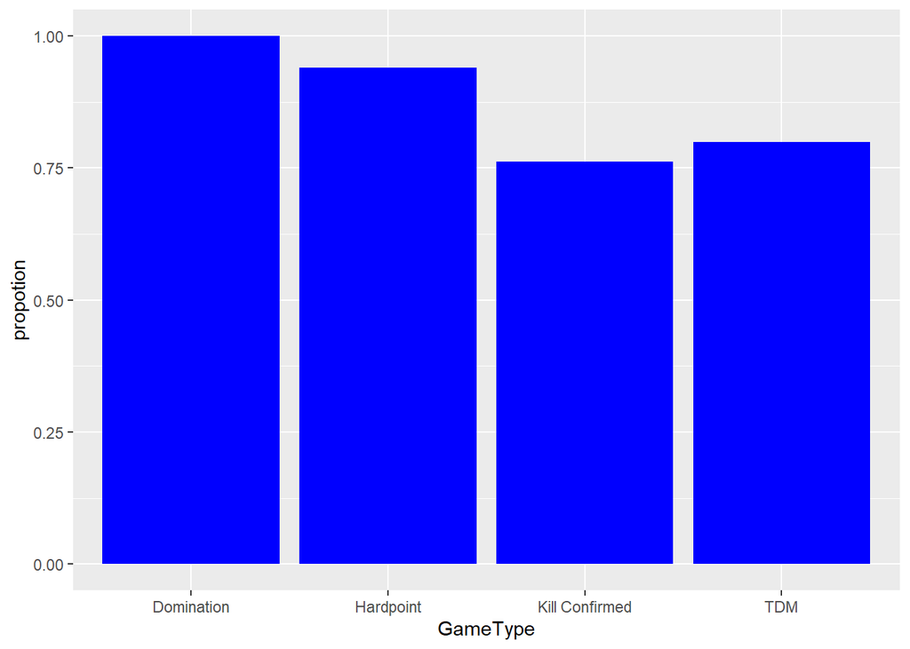

```r
TotalNum %>%
  ggplot(aes(x = GameType, y = propotion)) +
  geom_bar(stat="identity", fill = "blue")
```

Based on the proportion and graph, the domination is most likely to reach the score limit.

## Task 2

To find the predictor associated with the TotalXP, we first check are there predictors with lots of missing value.

```r
colSums(is.na(Allplayer2))
```

```
##           Map1           Map2         Choice        MapVote           Date
##              0              0              0              0              0
##    FullPartial        ResultA        ResultB   Eliminations         Deaths
##              0             31             31             31             31
##          Score         Damage        TotalXP  PrimaryWeapon         XPType
##             31             31             31              0              0
##  DidPlayerVote       GameType       Confirms         Denies     Objectives
##              0              0            819            819            801
## ObjectiveKills       Captures       Diffuses         Plants      Detonates
##            568            821            839            839            839
##       Deposits       Time_Sec       Time_Min     ScoreLimit      TimeLimit
##            839            586            586              0              0
```

By using is.na(), we find out that most of values are missing for Confirms, Denies, Objectives, ObjectiveKills, Captures, Diffuses, Plants, Detonates, Deposits, Time_Sec, and Time_Min. As a result, we don’t consider them as our predictors.

At the same time, we find out that there are some missing values in ResultA, ResultB, Eliminations, Deaths, Score, and Damage. We decide to remove all rows with these missing values. ResultA and ResultB actually represents whether the player win the game. As a result, we set new indicators called Win, Loss, and Draw based on the ResultA and ResultB.

In addition, even though the number of NA for categorical variable like Map1 and Map2 are 0, when we check the data, we see there are many blanks in these columns. Since these categorical variables have too many levels, which need to build a lot indicators for the model, we decide not to use Map1, Map2, Choice, MapVote, Date, and DidpPlayerVote as our predictors.

```r
#Select variables and creat new indicators
Allplayer3 <-
  Allplayer2 %>%
  select(TotalXP, FullPartial, ResultA, ResultB, Eliminations, Deaths, Score, Damage, XPType, GameType) %>%
  mutate(Win = ifelse(ResultA > ResultB, 1, 0),
         Loss = ifelse(ResultA < ResultB, 1, 0),
         Draw = ifelse(ResultA == ResultB, 1, 0)) %>%
  select(!ResultA) %>%
  select(!ResultB) %>%
  na.omit()
```

We try to build the model based on Allplayer3 dataset. However, we find that R automatically create 2 indicators for the XPType, which should only contain 2 levels. To solve this problem, we go back and check the level of XPType.

```r
#Check the level of XPTYpe
levels(as.factor(Allplayer3$XPType))
```

```
## [1] "10% Boost"        "Double XP + 10%"  "Double XP + 10% "
```

By using levels(), we find that there are three levels in total. There should be no difference between “Double XP + 10%” and “Double XP + 10%”. We think this may be a typo in the dataset so we decide to combine them together.

```r
#Fix the typo
Allplayer3["XPType"][Allplayer3["XPType"] == "Double XP + 10% "] <- "Double XP + 10%"
```

```r
#Build the multiple linear regression model
model1 <- lm(TotalXP ~ ., Allplayer3)
summary(model1)
```

```
##
## Call:
## lm(formula = TotalXP ~ ., data = Allplayer3)
##
## Residuals:
##     Min      1Q  Median      3Q     Max
## -9439.7 -2255.7  -328.1  1865.3 20674.6
##
## Coefficients: (1 not defined because of singularities)
##                          Estimate Std. Error t value Pr(>|t|)
## (Intercept)             2748.1636  1930.6147   1.423 0.154993
## FullPartialPartial        61.0811   486.1140   0.126 0.900039
## Eliminations             200.7945    40.2333   4.991 7.39e-07 ***
## Deaths                   127.4939    28.7772   4.430 1.07e-05 ***
## Score                      1.3149     0.1763   7.458 2.29e-13 ***
## Damage                     0.5076     0.1398   3.630 0.000301 ***
## XPTypeDouble XP + 10%   7571.0470   291.7338  25.952  < 2e-16 ***
## GameTypeHardpoint        -98.0993  1048.0589  -0.094 0.925450
## GameTypeKill Confirmed  -860.5551  1335.0151  -0.645 0.519370
## GameTypeTDM             -617.4284  1052.9302  -0.586 0.557779
## Win                    -1286.8914  1535.6342  -0.838 0.402271
## Loss                   -3146.2741  1537.8469  -2.046 0.041095 *
## Draw                           NA         NA      NA       NA
## ---
## Signif. codes:  0 '***' 0.001 '**' 0.01 '*' 0.05 '.' 0.1 ' ' 1
##
## Residual standard error: 3700 on 796 degrees of freedom
## Multiple R-squared:  0.7222, Adjusted R-squared:  0.7183
## F-statistic: 188.1 on 11 and 796 DF,  p-value: < 2.2e-16
```

```r
#Backward elimination
step(model1, direction = ("backward"))
```

```
## Start:  AIC=13288.95
## TotalXP ~ FullPartial + Eliminations + Deaths + Score + Damage +
##     XPType + GameType + Win + Loss + Draw
##
##
## Step:  AIC=13288.95
## TotalXP ~ FullPartial + Eliminations + Deaths + Score + Damage +
##     XPType + GameType + Win + Loss
##
##                Df  Sum of Sq        RSS   AIC
## - GameType      3   33078728 1.0928e+10 13285
## - FullPartial   1     216100 1.0895e+10 13287
## - Win           1    9612289 1.0905e+10 13288
## <none>                       1.0895e+10 13289
## - Loss          1   57290873 1.0952e+10 13291
## - Damage        1  180379478 1.1075e+10 13300
## - Deaths        1  268659230 1.1164e+10 13307
## - Eliminations  1  340919349 1.1236e+10 13312
## - Score         1  761402322 1.1657e+10 13342
## - XPType        1 9218429507 2.0114e+10 13782
##
## Step:  AIC=13285.4
## TotalXP ~ FullPartial + Eliminations + Deaths + Score + Damage +
##     XPType + Win + Loss
##
##                Df  Sum of Sq        RSS   AIC
## - FullPartial   1    3463974 1.0932e+10 13284
## - Win           1    8719565 1.0937e+10 13284
## <none>                       1.0928e+10 13285
## - Loss          1   58029202 1.0986e+10 13288
## - Damage        1  193275000 1.1121e+10 13298
## - Eliminations  1  401027691 1.1329e+10 13312
## - Deaths        1  431388046 1.1360e+10 13315
## - Score         1  751662963 1.1680e+10 13337
## - XPType        1 9231427815 2.0160e+10 13778
##
## Step:  AIC=13283.66
## TotalXP ~ Eliminations + Deaths + Score + Damage + XPType + Win +
##     Loss
##
##                Df  Sum of Sq        RSS   AIC
## - Win           1    9098048 1.0941e+10 13282
## <none>                       1.0932e+10 13284
## - Loss          1   58508016 1.0990e+10 13286
## - Damage        1  196482968 1.1128e+10 13296
## - Eliminations  1  399365733 1.1331e+10 13311
## - Deaths        1  436737675 1.1368e+10 13313
## - Score         1  751688156 1.1683e+10 13335
## - XPType        1 9360311612 2.0292e+10 13782
##
## Step:  AIC=13282.33
## TotalXP ~ Eliminations + Deaths + Score + Damage + XPType + Loss
##
##                Df  Sum of Sq        RSS   AIC
## <none>                       1.0941e+10 13282
## - Damage        1  191617264 1.1132e+10 13294
## - Eliminations  1  401210826 1.1342e+10 13309
## - Deaths        1  440181209 1.1381e+10 13312
## - Loss          1  660200260 1.1601e+10 13328
## - Score         1  752217913 1.1693e+10 13334
## - XPType        1 9386788129 2.0328e+10 13781
```

```
##
## Call:
## lm(formula = TotalXP ~ Eliminations + Deaths + Score + Damage +
##     XPType + Loss, data = Allplayer3)
##
## Coefficients:
##           (Intercept)           Eliminations                 Deaths
##               763.608                212.214                143.099
##                 Score                 Damage  XPTypeDouble XP + 10%
##                 1.262                  0.519               7531.555
##                  Loss
##             -1935.928
```

By using step() for the backward elimination, we find that Damage, Eliminations, Deaths, Loss, Score, XPType are the best predictors associated with the TotalXP because their AIC is the lowest.

```r
#Build the new multiple linear regression model based on the predictor we get
model2 <- lm(TotalXP ~ Damage + Eliminations + Deaths + Loss + Score + XPType, Allplayer3)
summary(model2)
```

```
##
## Call:
## lm(formula = TotalXP ~ Damage + Eliminations + Deaths + Loss +
##     Score + XPType, data = Allplayer3)
##
## Residuals:
##     Min      1Q  Median      3Q     Max
## -9534.9 -2279.4  -364.3  1883.9 20505.0
##
## Coefficients:
##                         Estimate Std. Error t value Pr(>|t|)
## (Intercept)             763.6080   495.6565   1.541 0.123809
## Damage                    0.5190     0.1386   3.746 0.000193 ***
## Eliminations            212.2143    39.1558   5.420 7.90e-08 ***
## Deaths                  143.0991    25.2074   5.677 1.92e-08 ***
## Loss                  -1935.9283   278.4574  -6.952 7.46e-12 ***
## Score                     1.2624     0.1701   7.421 2.97e-13 ***
## XPTypeDouble XP + 10%  7531.5549   287.2986  26.215  < 2e-16 ***
## ---
## Signif. codes:  0 '***' 0.001 '**' 0.01 '*' 0.05 '.' 0.1 ' ' 1
##
## Residual standard error: 3696 on 801 degrees of freedom
## Multiple R-squared:  0.721,  Adjusted R-squared:  0.7189
## F-statistic:   345 on 6 and 801 DF,  p-value: < 2.2e-16
```

For example, as the Eliminations increases or decreases by 1, the TotalXP will increase or decrease by 212.2143.

## Task 3

Research Question: Can we predict the game result based on player’s performance during the game including Eliminations, Deaths, and Damage?

In this question, we will use Win as our indicator for game result and use Eliminations, Deaths, and Damage as our predictors. To solve this question, we are going to use kNN classfication, random forest, and SVM. kNN classfication is from the FNN package. It is used for estimating the likelihood that a data point will become a member of one group or another based on what group the data points nearest to it belong to. Random forest is from the randomForest package. It operates by constructing a multitude of decision trees at training time with the output of the class selected by most trees. SVM is from the e1071 package. It maps training examples to points in space so as to maximize the width of the gap between the two categories. New examples are then mapped into that same space and predicted to belong to a category based on which side of the gap they fall.

As we learned in the class, whether the data is scaled would affect the model and result. As a result, we decide to build models seperatly with scaled and unscaled data. We start with the scaled data.

```r
#Scale the data and make the train/test split
xvars <- c("Eliminations", "Deaths", "Damage")
Allplayer4 <-
  Allplayer3
Allplayer4[ , xvars] <- scale(Allplayer4[ , xvars],
                      center = TRUE,
                      scale = TRUE)

set.seed(123)
train_ind <- sample(1:nrow(Allplayer4), floor(0.8 * nrow(Allplayer4)))
set.seed(NULL)

Train <- Allplayer4[train_ind, ]
Test <- Allplayer4[-train_ind, ]
```

Model 1: kNN classification

```r
#Find the best k
maxk <- 50
accuracy_vec <- rep(NA, maxk)
for(i in 2:maxk){
  knn_res_temp <- knn(train = Train[ , xvars, drop = FALSE],
                      test = Test[, xvars, drop = FALSE],
                      cl = Train$Win,
                      k = i)
  knn_res_temp[1:nrow(Test)]
  Testk <-
    Test %>%
    mutate(pred_win = knn_res_temp)
  accuracy_vec[i] = mean(Testk$pred_win == Testk$Win)
}
which.max(accuracy_vec)
```

```
## [1] 28
```

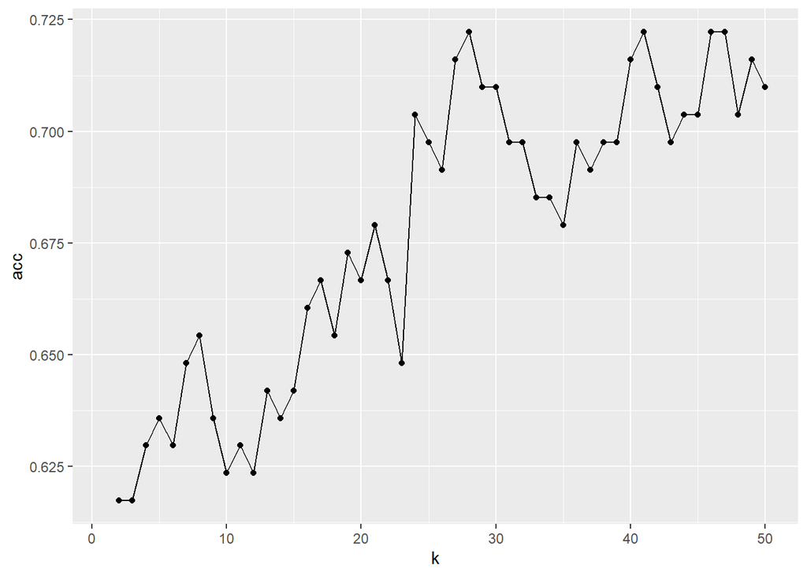

```r
#Plot shows the different k with their accuracy
temp_df <- data.frame(k = 1:maxk, acc = accuracy_vec)
temp_df %>%
  ggplot(aes(x = k, y = acc)) +
  geom_point() +
  geom_line()
```

```r
#Build the kNN model based on the best k we found
knn_res <- knn(train = Train[ , xvars, drop = FALSE],
               test = Test[, xvars, drop = FALSE],
               cl = Train$Win,
               k = 28)
knn_res[1:nrow(Test)]
```

```
##   [1] 0 1 1 1 1 1 0 1 0 1 1 1 1 1 1 1 1 0 1 1 1 0 1 0 0 1 0 1 0 0 1 1 1 0 1 0 1
##  [38] 1 1 1 0 0 1 1 0 0 0 0 0 1 1 1 1 0 0 1 1 1 1 0 1 1 1 1 0 1 0 0 0 1 0 0 1 0
##  [75] 1 1 0 0 1 1 1 1 0 1 0 1 0 1 1 0 1 0 1 1 1 1 0 0 1 1 1 1 1 0 0 0 1 1 1 1 1
## [112] 0 0 1 1 1 1 1 0 0 0 1 1 0 1 0 1 0 1 1 0 0 1 0 0 0 1 0 0 1 1 1 0 1 1 0 0 0
## [149] 0 1 0 0 0 0 0 0 0 1 1 1 0 0
## Levels: 0 1
```

```r
#Calculate the accuracy for kNN model
Teste <-
  Test %>%
  mutate(pred_win = knn_res)
#Accuracy
mean(Teste$pred_win == Teste$Win)
```

```
## [1] 0.7222222
```

Model 2: Random Forest

```r
#Build the random forest model with ntree = 500 and mtry = 3
rf <- randomForest(as.factor(Win) ~ Eliminations + Deaths + Damage, data = Train, ntree = 500, mtry = 3)
pred_prob <- predict(rf, newdata = Test, type = "prob")
pred_win <- predict(rf, newdata = Test, type = "response")
#Accuracy
mean(pred_win == Test$Win)
```

```
## [1] 0.6419753
```

Model 3: SVM

```r
#Build the SVM model with cost = .1
svm <- svm(Win ~ Eliminations + Deaths + Damage, data = Train, kernel = "linear", cost = .1, type = "C-classification")
pred_prob_svm <- predict(svm, newdata = Test, type = "class")
#Accuracy
mean(pred_prob_svm == Test$Win)
```

```
## [1] 0.6975309
```

After that, we focus on unscaled data and try to compare the result.

```r
#Use the original data and do the train/test split
xvars <- c("Eliminations", "Deaths", "Damage")

set.seed(123)
train_ind2 <- sample(1:nrow(Allplayer3), floor(0.8 * nrow(Allplayer3)))
set.seed(NULL)

Train2 <- Allplayer3[train_ind2, ]
Test2 <- Allplayer3[-train_ind2, ]
```

Model 1: kNN classfication

```r
#Find the best k
maxk2 <- 50
accuracy_vec2 <- rep(NA, maxk2)
for(i in 2:maxk2){
  knn_res_temp2 <- knn(train = Train2[ , xvars, drop = FALSE],
                      test = Test2[, xvars, drop = FALSE],
                      cl = Train2$Win,
                      k = i)
  knn_res_temp2[1:nrow(Test2)]
  Testk2 <-
    Test2 %>%
    mutate(pred_win = knn_res_temp2)
  accuracy_vec2[i] = mean(Testk2$pred_win == Testk2$Win)
}
which.max(accuracy_vec2)
```

```
## [1] 3
```

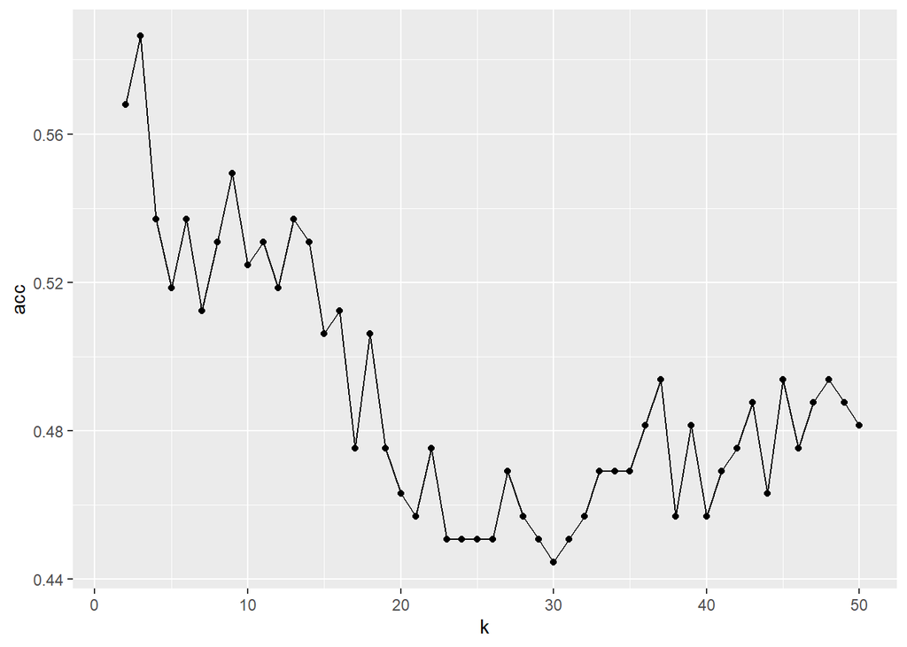

```r
#Plot shows the different k with their accuracy
temp_df2 <- data.frame(k = 1:maxk2, acc = accuracy_vec2)
temp_df2 %>%
  ggplot(aes(x = k, y = acc)) +
  geom_point() +
  geom_line()
```

```r
#Build the kNN model based on the best k we found

knn_res2 <- knn(train = Train2[ , xvars, drop = FALSE],
               test = Test2[, xvars, drop = FALSE],
               cl = Train2$Win,
               k = 3)
knn_res2[1:nrow(Test2)]
```

```
##   [1] 1 1 1 1 1 0 1 0 0 1 1 0 1 1 1 1 1 1 0 1 0 0 1 1 1 1 0 1 0 0 1 1 1 0 1 0 0
##  [38] 0 1 1 0 1 1 0 1 1 1 0 0 1 0 0 0 1 1 1 1 1 0 0 1 1 1 0 1 1 1 1 1 1 1 0 0 1
##  [75] 1 1 0 1 0 0 1 0 0 1 0 1 1 0 1 1 0 1 1 1 1 0 0 0 0 1 1 1 0 1 0 1 0 0 0 1 1
## [112] 0 1 1 1 0 1 1 1 0 1 1 1 0 1 0 1 1 0 1 0 0 1 1 0 1 1 0 0 0 1 1 0 1 1 0 0 0
## [149] 0 1 0 1 1 1 0 1 1 0 0 1 0 0
## Levels: 0 1
```

```r
#Calculate the accuracy for kNN model
Teste2 <-
  Test2 %>%
  mutate(pred_win = knn_res2)
#Accuracy
mean(Teste2$pred_win == Teste2$Win)
```

```
## [1] 0.5864198
```

Model 2: Random Forest

```r
#Build the random forest model with ntree = 500 and mtry = 3
rf2 <- randomForest(as.factor(Win) ~ Eliminations + Deaths + Damage, data = Train2, ntree = 500, mtry = 3)
pred_prob2 <- predict(rf2, newdata = Test2, type = "prob")
pred_win2 <- predict(rf2, newdata = Test2, type = "response")
#Accuracy
mean(pred_win2 == Test2$Win)
```

```
## [1] 0.6666667
```

Model 3: SVM

```r
#Build the SVM model with cost = 0.1
svm2 <- svm(Win ~ Eliminations + Deaths + Damage, data = Train2, kernel = "linear", cost = .1, type = "C-classification")
pred_prob_svm2 <- predict(svm2, newdata = Test2, type = "class")
#Accuracy
mean(pred_prob_svm2 == Test2$Win)
```

```
## [1] 0.6975309
```

Conclusion: We can predict the game result based on player’s Elimination, Deaths, and Damage by using kNN classfication, random forest, and svm. kNN classfication works the best with an accuracy of 0.722.